# Airline Performance Analysis

## by Uche Ofia

## Investigation Overview

The goal of this exploration was to try and find patterns in flight data to predict flights that could be delayed, diverted or cancelled. The main aspects focused on were delay times, airline carriers and day of week.

## Dataset Overview

The data used here is a subset of the original data. This data contains over 30 million flight records between the year 2000 and 2008. The variables analyzed include arrival delay, departure delay, airline carrier, cancelled flights, diverted flights and delayed flights.

## Causes of Cancelled Flights

Consistently across the years, the major cause of cancelled flights was due to circumstances within the airline company's control, such as fueling, maintenance and crew problems. That is closely followed by weather delays.

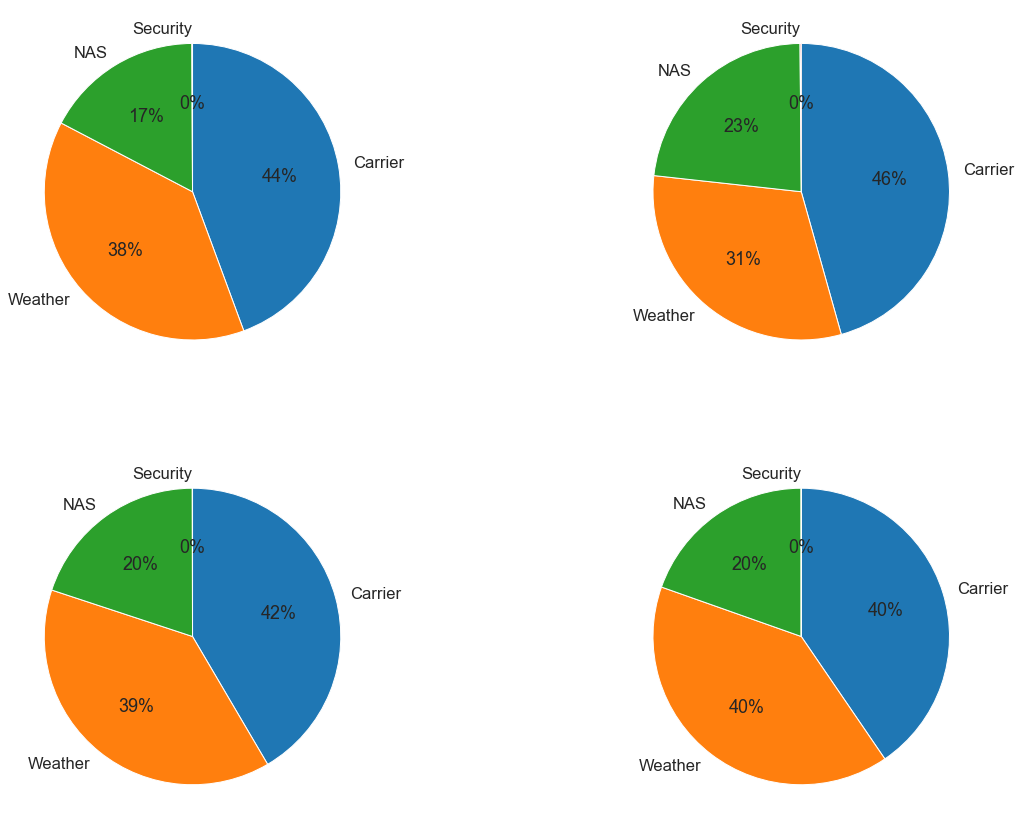

## Average Delay Times By Weekday

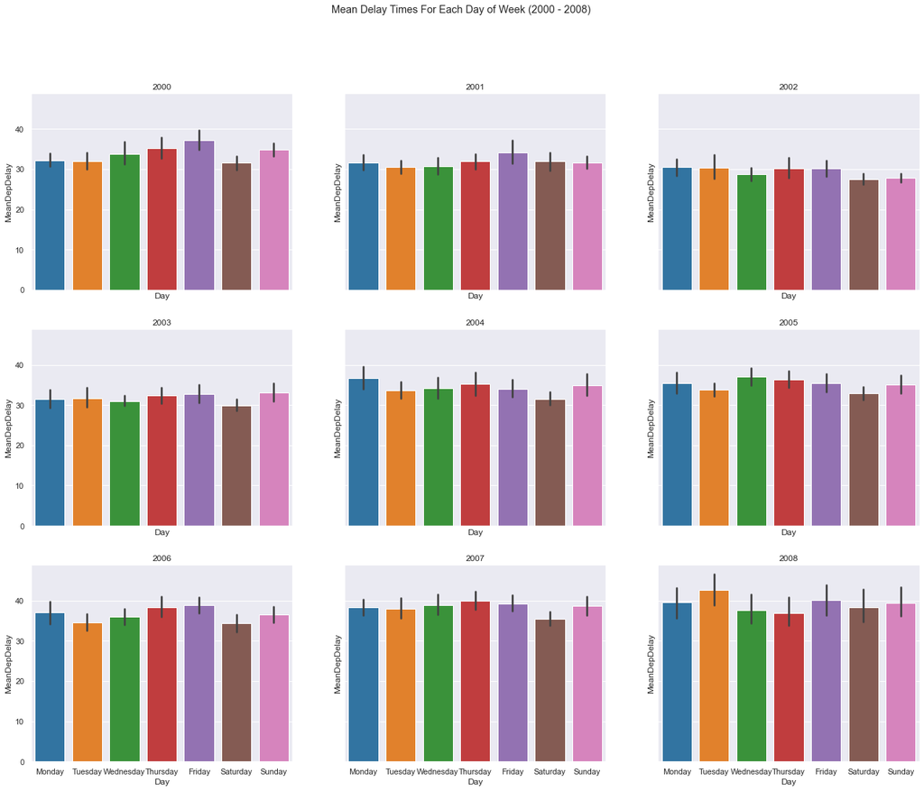

## Carrier Performance

American Eagle Airlines Inc. has the highest number of cancelled flights by a wide margin (over 20,000), followed by American Airlines Inc. with over 17,000 cancelled flights. Numbers for diverted flights were generally much lower than that of cancelled flights with American Airlines Inc. and Southwest Airlines Co. coming out on top.

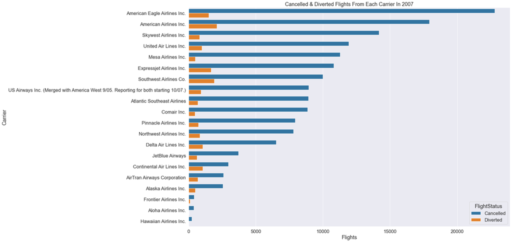